# 5.3 Cubic splines

**Definition 5.3.1 (Cubic spline)**

A *cubic spline* is a piecewise cubic function that has two continuous derivatives everywhere.

We use $S(x)$ to denote the cubic spline interpolant.  
As before, suppose that distinct nodes $t_0 < t_1 < \cdots < t_n$ (not necessarily equally spaced)  
and data $y_0, \ldots, y_n$ are given.

For any $k = 1, \ldots, n$, the spline $S(x)$ on the interval $[t_{k-1}, t_k]$ is by definition a cubic polynomial $S_k(x)$,  
which we express as

$S_k(x) = a_k + b_k(x - t_{k-1}) + c_k(x - t_{k-1})^2 + d_k(x - t_{k-1})^3,\quad k = 1, \ldots, n.$

where $a_k, b_k, c_k, d_k$ are values to be determined.  
Overall there are $4n$ such undetermined coefficients.

## 5.3.1 Smoothness conditions

**1. Interpolation by $S_k$ at both of its endpoints.**

Algebraically we require $S_k(t_{k-1}) = y_{k-1}$ and $S_k(t_k) = y_k$ for every $k = 1, \ldots, n$.  
In terms of (5.3.1), these conditions are

$a_k = y_{k-1}, \quad \text{(5.3.2)}$

$a_k + b_k h_k + c_k h_k^2 + d_k h_k^3 = y_k, \quad k = 1, \ldots, n. \quad \text{(5.3.3)}$

where we have used the definition

$h_k = t_k - t_{k-1}, \quad k = 1, \ldots, n. \quad \text{(5.3.4)}$

The values of $h_k$ are derived from the nodes. Crucially, the unknown coefficients appear only *linearly* in the constraint equations.  
So we will express the constraints using linear algebra.

The left endpoint interpolation constraints (5.3.2) are, in matrix form,

$\begin{bmatrix} I & 0 & 0 & 0 \end{bmatrix} \begin{bmatrix} a \\ b \\ c \\ d \end{bmatrix} = \begin{bmatrix} y_0 \\ \vdots \\ y_{n-1} \end{bmatrix}, \quad \text{(5.3.5)}$

with $I$ being an $n \times n$ identity.  
The right endpoint interpolation constraints, given by (5.3.3), become

$\begin{bmatrix} I & H & H^2 & H^3 \end{bmatrix} \begin{bmatrix} a \\ b \\ c \\ d \end{bmatrix} = \begin{bmatrix} y_1 \\ \vdots \\ y_n \end{bmatrix}, \quad \text{(5.3.6)}$

where we have defined the diagonal matrix

$H = \begin{bmatrix} h_1 & & \\ & h_2 & \\ & & \ddots \\ & & & h_n \end{bmatrix}. \quad \text{(5.3.7)}$

Collectively, (5.3.5) and (5.3.6) express $2n$ scalar constraints on the unknowns.

**2. Continuity of $S'(x)$ at interior nodes.**

We do not know what the slope of the interpolant should be at the nodes,  
but we do want the same slope whether a node is approached from the left or the right.  
Thus, we obtain constraints at the nodes that sit between two neighboring piecewise definitions,  
so that $S'_1(t_1) = S'_2(t_1)$, and so on. Altogether these are

$b_k + 2c_k h_k + 3d_k h_k^2 = b_{k+1}, \quad k = 1, \ldots, n-1. \quad \text{(5.3.8)}$

Moving the unknowns to the left side, as a system these become

$\mathbf{E} [0 \quad \mathbf{J} \quad 2\mathbf{H} \quad 3\mathbf{H}^2] \begin{bmatrix} a \\ b \\ c \\ d \end{bmatrix} = 0, \quad \text{(5.3.9)}$

where now we have defined

$\mathbf{J} = \begin{bmatrix} 1 & -1 \\ 1 & \ddots & \ddots \\ & \ddots & 1 & -1 \\ & & 1 & -1 \end{bmatrix}, \quad \text{(5.3.10)}$

and $\mathbf{E}$ is the $(n-1) \times n$ matrix resulting from deleting the last row of the identity:

$\mathbf{E} = \begin{bmatrix} 1 & 0 \\ & 1 & 0 \\ & & \ddots & \ddots \\ & & & 1 & 0 \end{bmatrix}. \quad \text{(5.3.11)}$

Left-multiplying by $\mathbf{E}$ deletes the last row of any matrix or vector.  
Hence, (5.3.9) represents $n-1$ constraints on the unknowns.  
(Remember, there are only $n-1$ interior nodes.)

**3. Continuity of $S''(x)$ at interior nodes.**

These again apply only at the interior nodes $t_1, \ldots, t_{n-1}$,  
in the form $S''_1(t_1) = S''_2(t_1)$ and so on.  
Using (5.3.1) once more, we obtain

$2c_k + 6d_k h_k = 2c_{k+1}, \quad k = 1, \ldots, n-1. \quad \text{(5.3.12)}$

In system form (after canceling a factor of 2 from each side) we get

$\mathbf{E} [0 \quad 0 \quad \mathbf{J} \quad 3\mathbf{H}] \begin{bmatrix} a \\ b \\ c \\ d \end{bmatrix} = 0. \quad \text{(5.3.13)}$

## 5.3.2 End conditions

So far the equations (5.3.5), (5.3.6), (5.3.9), and (5.3.13) form  
$2n + (n - 1) + (n - 1) = 4n - 2$ linear conditions on the $4n$ unknowns  
in the piecewise definition (5.3.1). In order to obtain a square system,  
we must add two more constraints. If the application prescribes values for $S'$ or $S''$  
at the endpoints, those may be applied. Otherwise, there are two major alternatives:

- **Natural spline:**  
  $S''_1(t_0) = S''_n(t_n) = 0$
- **Not-a-knot spline:**  
  $S'''_1(t_1) = S'''_2(t_1), \quad S'''_{n-1}(t_{n-1}) = S'''_n(t_{n-1})$

While natural splines have important theoretical properties,  
not-a-knot splines give better pointwise accuracy,  
and they are the only type we consider further.

In the not-a-knot spline, the values and first three derivatives of the cubic polynomials  
$S_1$ and $S_2$ agree at the node $t_1$. Hence, they must be the same cubic polynomial!  
The same is true of $S_{n-1}$ and $S_n$.  
We could use these facts to eliminate some of the undetermined coefficients  
from our linear system of constraints. However, rather than rework the algebra,  
we just append two more rows to the system, expressing the conditions

$d_1 = d_2, \quad d_{n-1} = d_n. \quad \text{(5.3.14)}$

Collectively, (5.3.5), (5.3.6), (5.3.9), (5.3.13), and (5.3.14) comprise  
a square linear system of size $4n$ that can be solved for the coefficients  
defining the piecewise cubics in (5.3.1).

This is a major difference from the piecewise linear interpolant,  
for which there is no linear system to solve.  
Indeed, while it is possible to find a basis for the cubic spline interpolant  
analogous to the hat functions, it is not possible in closed form to construct  
a *cardinal basis*, so the solution of a linear system cannot be avoided.

## 5.3.3 Implementation

```python
import numpy as np
from numpy import exp, sin, cos, linspace, array
import matplotlib.pyplot as plt
from matplotlib.pyplot import subplots, xlabel, ylabel, loglog, legend
```

```python
def spinterp(t, y):
    """
    spinterp(t, y)

    Create a cubic not-a-knot spline interpolating function for data values in y given at nodes in t.
    """
    n = len(t) - 1
    h = [t[i + 1] - t[i] for i in range(n)]

    # Preliminary definitions.
    Z = np.zeros([n, n])
    I = np.eye(n)
    E = I[: n - 1, :]
    J = np.eye(n) + np.diag(-np.ones(n - 1), 1)
    H = np.diag(h)

    # Left endpoint interpolation:
    AL = np.hstack([I, Z, Z, Z])
    vL = y[:-1]

    # Right endpoint interpolation:
    AR = np.hstack([I, H, H**2, H**3])
    vR = y[1:]

    # Continuity of first derivative:
    A1 = E @ np.hstack([Z, J, 2 * H, 3 * H**2])
    v1 = np.zeros(n - 1)

    # Continuity of second derivative:
    A2 = E @ np.hstack([Z, Z, J, 3 * H])
    v2 = np.zeros(n - 1)

    # Not-a-knot conditions:
    nakL = np.hstack([np.zeros(3 * n), np.hstack([1, -1, np.zeros(n - 2)])])
    nakR = np.hstack([np.zeros(3 * n), np.hstack([np.zeros(n - 2), 1, -1])])

    # Assemble and solve the full system.
    A = np.vstack([AL, AR, A1, A2, nakL, nakR])
    v = np.hstack([vL, vR, v1, v2, 0, 0])
    z = solve(A, v)

    # Break the coefficients into separate vectors.
    rows = np.arange(n)
    a = z[rows]
    b = z[n + rows]
    c = z[2 * n + rows]
    d = z[3 * n + rows]
    S = [np.poly1d([d[k], c[k], b[k], a[k]]) for k in range(n)]

    # This function evaluates the spline when called with a value for x.
    def evaluate(x):
        f = np.zeros(x.shape)
        for k in range(n):
            # Evaluate this piece's cubic at the points inside it.
            index = (x >= t[k]) & (x <= t[k + 1])
            f[index] = S[k](x[index] - t[k])
        return f

    return evaluate
```

### Example 5.3.1(Cubic splines)

For illustration, here is a spline interpolant using just a few nodes.

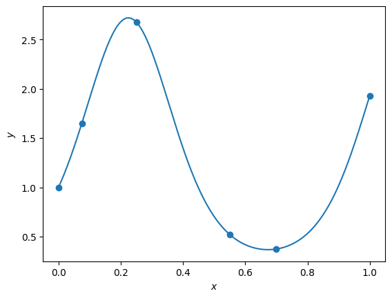

```python
f = lambda x: exp(sin(7 * x))

x = linspace(0, 1, 500)
fig, ax = subplots()
ax.plot(x, f(x), label="function")

t = array([0, 0.075, 0.25, 0.55, 0.7, 1])  # nodes
y = f(t)  # values at nodes

xlabel("$x$")
ylabel("$y$")
ax.scatter(t, y, label="nodes")
```

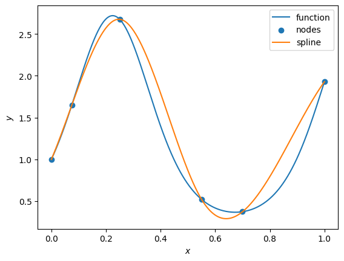

```python
S = spinterp(t, y)
ax.plot(x, S(x), label="spline")
ax.legend()
fig
```

Now we look at the convergence rate as the number of nodes increases.

```python
N = np.floor(2 ** linspace(3, 8, 17)).astype(int)
err = np.zeros(N.size)
for i, n in enumerate(N):
    t = linspace(0, 1, n + 1)  # interpolation nodes
    p = spinterp(t, f(t))
    err[i] = max(abs(f(x) - p(x)))
print(err)
```

```
[3.05633432e-02 2.39601586e-02 1.68054365e-02 7.64098319e-03
 2.89472870e-03 1.34574135e-03 5.43142890e-04 2.28104055e-04
 9.17629364e-05 3.71552636e-05 1.56015311e-05 6.34890672e-06
 2.53866817e-06 9.98323636e-07 4.35498457e-07 1.75251504e-07
 6.59321329e-08]
```

Since we expect convergence that is $O(h^4) = O(n^{-4})$,  
we use a log–log graph of error and expect a straight line of slope $-4$.

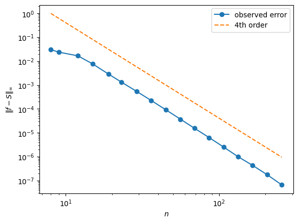

```python
order4 = (N / N[0]) ** (-4)
loglog(N, err, "-o", label="observed error")
loglog(N, order4, "--", label="4th order")
xlabel("$n$")
ylabel("$\|f-S\|_\infty$")
legend();
```

Besides having more smoothness than a piecewise linear interpolant, the not-a-knot cubic spline improves the order of accuracy to 4.

**Theorem 5.3.1**

Suppose that $f(x)$ has four continuous derivatives in $[a, b]$ (i.e., $f \in C^4[a, b]$).  
Let $S_n(x)$ be the not-a-knot cubic spline interpolant of $(t_i, f(t_i))$ for $i = 0, \ldots, n$,  
where $t_i = a + i h$ and $h = (b - a)/n$.  
Then for all sufficiently small $h$, there is a constant $C > 0$ such that

$$ \|f - S_n\|_\infty \leq C h^4. \quad \text{(5.3.15)} $$

# 5.4 Finite differences

**Definition 5.4.1 (Finite-difference formula)**

A *finite-difference formula* is a list of values $a_{-p}, \ldots, a_q$, called *weights*,  
such that for all $f$ in some class of functions,

$$ f'(x) \approx \frac{1}{h} \sum_{k=-p}^{q} a_k f(x + k h). \quad \text{(5.4.1)} $$

The weights are independent of $f$ and $h$.  
The formula is said to be *convergent* if the approximation becomes equality  
in the limit $h \to 0$ for a suitable class of functions.

**Definition 5.4.2 (Forward, backward, and centered FD formulas)**

A *forward difference formula* is characterized by (5.4.1) with $p = 0$,  
a *backward difference formula* has $q = 0$,  
and a *centered difference formula* has $p = q$.

The simplest example of a forward difference formula is inspired by  
the familiar limit definition of a derivative:

$$ f'(x) \approx \frac{f(x + h) - f(x)}{h}, \quad \text{(5.4.2)} $$

which is (5.4.1) with $p = 0$, $q = 1$, $a_0 = -1$, and $a_1 = 1$.  
Analogously, we have the backward difference

$$ f'(x) \approx \frac{f(x) - f(x - h)}{h}, \quad \text{(5.4.3)} $$

in which $p = 1$, $q = 0$.

**Example 5.4.1**

Suppose $f(x) = x^2$, and we take $h = \tfrac{1}{4}$ over the interval $[0, 1]$.  
This results in the nodes $0, \tfrac{1}{4}, \tfrac{1}{2}, \tfrac{3}{4}, 1$.  
We evaluate $f$ at the nodes to get

$$ f(0) = 0, \quad f\!\left(\tfrac{1}{4}\right) = \tfrac{1}{16}, \quad f\!\left(\tfrac{1}{2}\right) = \tfrac{1}{4}, \quad f\!\left(\tfrac{3}{4}\right) = \tfrac{9}{16}, \quad f(1) = 1. $$

This gives four forward difference estimates,

$$ f'(0) \approx 4\!\left(\tfrac{1}{16} - 0\right), \quad f'\!\left(\tfrac{1}{4}\right) \approx 4\!\left(\tfrac{1}{4} - \tfrac{1}{16}\right), $$$$ f'\!\left(\tfrac{1}{2}\right) \approx 4\!\left(\tfrac{9}{16} - \tfrac{1}{4}\right), \quad f'\!\left(\tfrac{3}{4}\right) \approx 4\!\left(1 - \tfrac{9}{16}\right). $$

We also get four backward difference estimates,

$$ f'\!\left(\tfrac{1}{4}\right) \approx 4\!\left(\tfrac{1}{16} - 0\right), \quad f'\!\left(\tfrac{1}{2}\right) \approx 4\!\left(\tfrac{1}{4} - \tfrac{1}{16}\right), $$$$ f'\!\left(\tfrac{3}{4}\right) \approx 4\!\left(\tfrac{9}{16} - \tfrac{1}{4}\right), \quad f'(1) \approx 4\!\left(1 - \tfrac{9}{16}\right). $$

Notice that it’s the same four differences each time,  
but we’re interpreting them as derivative estimates at different nodes.

As pointed out in *Example 5.4.1*, the only real distinction between (5.4.2) and (5.4.3)  
is whether we think that $f'$ is being evaluated at the left node or the right one.  
Symmetry would suggest that we should evaluate it halfway between.  
That is the motivation behind centered difference formulas.

Let’s derive the shortest centered formula using $p = q = 1$.  
For simplicity, we will set $x = 0$ without affecting the result.  
This means that $f(-h)$, $f(0)$, and $f(h)$ are all available in (5.4.1).

Note that (5.4.2) is simply the slope of the line through the points $(0, f(0))$ and $(h, f(h))$.  
One route to using all three function values is to differentiate the quadratic polynomial  
that interpolates $(-h, f(-h))$ as well (see *Exercise 5.4.1*):

$$ Q(x) = \frac{x(x - h)}{2h^2} f(-h) - \frac{x^2 - h^2}{h^2} f(0) + \frac{x(x + h)}{2h^2} f(h). \quad \text{(5.4.4)} $$

This leads to

$$ f'(0) \approx Q'(0) = \frac{f(h) - f(-h)}{2h}. \quad \text{(5.4.5)} $$

This result is equivalent to (5.4.1) with $p = q = 1$ and weights  
$a_{-1} = -\tfrac{1}{2}$, $a_0 = 0$, and $a_1 = \tfrac{1}{2}$.  
Observe that while the value of $f(0)$ was available during the derivation,  
its weight ends up being zero.

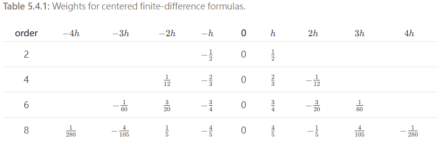

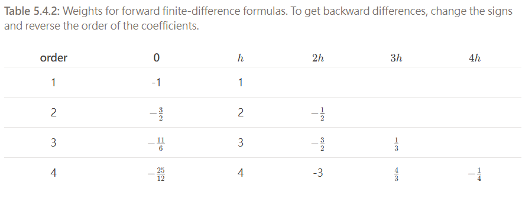

**Example 5.4.2**

According to the tables, here are three specific finite-difference formulas:

$$ f'(0) \approx \frac{1}{h} \left[ \tfrac{1}{12} f(-2h) - \tfrac{2}{3} f(-h) + \tfrac{2}{3} f(h) - \tfrac{1}{12} f(2h) \right], $$$$ f'(0) \approx \frac{1}{h} \left[ -\tfrac{3}{2} f(0) + 2 f(h) - \tfrac{1}{2} f(2h) \right], \quad \text{(5.4.6)} $$$$ f'(0) \approx \frac{1}{h} \left[ \tfrac{1}{2} f(-2h) - 2 f(-h) + \tfrac{3}{2} f(0) \right]. $$

### Example 5.4.3 (Finite differences)

If $f(x) = e^{\sin(x)}$, then $f'(0) = 1.$

```python
f = lambda x: exp(sin(x))
```

Here are the first two centered differences from Table 5.4.1.

```python
h = 0.05
CD2 = (-f(-h) + f(h)) / (2*h)
CD4 = (f(-2*h) - 8*f(-h) + 8*f(h) - f(2*h)) / (12*h)
print(f"CD2 is {CD2:.9f} and CD4 is {CD4:.9f}")
```

```
CD2 is 0.999999584 and CD4 is 1.000001663
```

Here are the first two forward differences from Table 5.4.2.

```python
FD1 = (-f(0) + f(h)) / h
FD2 = (-3*f(0) + 4*f(h) - f(2*h)) / (2*h)
print(f"FD1 is {FD1:.9f} and FD2 is {FD2:.9f}")
```

```
FD1 is 1.024983957 and FD2 is 1.000099611
```

Finally, here are the backward differences that come from reverse-negating the forward differences.

```python
BD1 = (-f(-h) + f(0)) / h
BD2 = (f(-2*h) - 4*f(-h) + 3*f(0)) / (2*h)
print(f"BD1 is {BD1:.9f} and BD2 is {BD2:.9f}")
```

```
BD1 is 0.975015210 and BD2 is 0.999912034
```

## 5.4.2 Higher derivatives

Many applications require the second derivative of a function.  
It’s tempting to use the finite difference of a finite difference.  
For example, applying (5.4.5) to $f'$ gives

$$ f''(0) \approx \frac{f'(h) - f'(-h)}{2h}. \quad \text{(5.4.7)} $$

Then applying (5.4.5) to approximate the appearances of $f'$ leads to

$$ f''(0) \approx \frac{f(-2h) - 2f(0) + f(2h)}{4h^2}. \quad \text{(5.4.8)} $$

This is a valid formula, but it uses values at $\pm 2h$ rather than the closer values at $\pm h$.  
A better and more generalizable tactic is to return to the quadratic $Q(x)$ in (5.4.4)  
and use $Q''(0)$ to approximate $f''(0)$. Doing so yields

$$ f''(0) \approx \frac{f(-h) - 2f(0) + f(h)}{h^2}, \quad \text{(5.4.9)} $$

which is the simplest *centered second-difference formula*.  
As with the first derivative, we can choose larger values of $p$ and $q$ in (5.4.1)  
to get new formulas, such as

$$ f''(0) \approx \frac{f(0) - 2f(h) + f(2h)}{h^2}, \quad \text{(5.4.10)} $$

and

$$ f''(0) \approx \frac{2f(0) - 5f(h) + 4f(2h) - f(3h)}{h^2}. \quad \text{(5.4.11)} $$

For the second derivative, converting a forward difference to a backward difference  
requires reversing the order of the weights, while *not* changing their signs.

### Example 5.4.4 (Finite differences for $f''$)

If $f(x) = e^{\sin(x)}$, then $f''(0) = 1.$

```python
f = lambda x: exp(sin(x))
```

Here is a centered estimate given by (5.4.9).

```python
h = 0.05
CD2 = (f(-h) - 2*f(0) + f(h)) / h**2
print(f"CD2 is {CD2:.9f}")
```

```
CD2 is 0.999374948
```

For the same $h$, here are forward estimates given by (5.4.10) and (5.4.11).

```python
FD1 = (f(0) - 2*f(h) + f(2*h)) / h**2
FD2 = (2*f(0) - 5*f(h) + 4*f(2*h) - f(3*h)) / h**2
print(f"FD1 is {FD1:.9f} and FD2 is {FD2:.9f}")
```

```
FD1 is 0.995373844 and FD2 is 1.007881148
```

Finally, here are the backward estimates that come from reversing (5.4.10) and (5.4.11).

```python
BD1 = (f(-2*h) - 2*f(-h) + f(0)) / h**2
BD2 = (-f(-3*h) + 4*f(-2*h) - 5*f(-h) + 2*f(0)) / h**2
print(f"BD1 is {BD1:.9f} and BD2 is {BD2:.9f}")
```

```
BD1 is 0.995872969 and BD2 is 1.005892819
```

## 5.4.3 Arbitrary nodes

Although function values at equally spaced nodes are a common and convenient situation,  
the node locations may be arbitrary.  
The general form of a finite-difference formula is

$$ f^{(m)}(0) \approx \sum_{k=0}^{r} c_{k,m} f(t_k). \quad \text{(5.4.12)} $$

We no longer assume equally spaced nodes, so there is no "$h$" to be used in the formula.  
As before, the weights may be applied after any translation of the independent variable.  
The weights again follow from the interpolate/differentiate recipe,  
but the algebra becomes complicated.

Fortunately, there is an elegant recursion known as *Fornberg’s algorithm*  
that can calculate these weights for any desired formula.  
We present it without derivation as *Function 5.4.1*.

### Fornberg’s algorithm for finite difference weights

```python
def fdweights(t, m):
    """
    fdweights(t, m)

    Return weights for the mth derivative of a function at zero using values at the
    nodes in vector t.
    """
    # This is a compact implementation, not an efficient one.

    def weight(t, m, r, k):
        # Recursion for one weight.
        # Input:
        #   t   nodes (vector)
        #   m   order of derivative sought
        #   r   number of nodes to use from t (<= length(t))
        #   k   index of node whose weight is found

        if (m < 0) or (m > r):  # undefined coeffs must be zero
            c = 0
        elif (m == 0) and (r == 0):  # base case of one-point interpolation
            c = 1
        else:  # generic recursion
            if k < r:
                denom = t[r] - t[k]
                c = (t[r] * weight(t, m, r-1, k) - m * weight(t, m-1, r-1, k)) / denom
            else:
                beta = np.prod(t[r-1] - t[:r-1]) / np.prod(t[r] - t[:r])
                c = beta * (m * weight(t, m-1, r-1, r-1) - t[r-1] * weight(t, m, r-1, r-1))
        return c

    r = len(t) - 1
    w = np.zeros(t.shape)
    return np.array([ weight(t, m, r, k) for k in range(r+1) ])
```

### Example 5.4.5 (Finite differences at arbitrary nodes)

We will estimate the derivative of $\cos(x^2)$ at $x = 0.5$ using five nodes.

```python
t = array([0.35, 0.5, 0.57, 0.6, 0.75])   # nodes
f = lambda x: cos(x**2)
dfdx = lambda x: -2 * x * sin(x**2)
exact_value = dfdx(0.5)
print(f"Exact value is {exact_value:.9f}")
```

```
Exact value is -0.247403959
```

```python
w = fdweights(t - 0.5, 1)
```

The finite-difference formula is a dot product (i.e., inner product) between the vector of weights and the vector of function values at the nodes.

```python
fd_value = np.dot(w, f(t))
print(f"FD value is {fd_value:.9f}")
print(abs(exact_value - fd_value))
```

```
FD value is -0.247307423
9.653634838793779e-05
```

We can reproduce the weights in the finite-difference tables by using equally spaced nodes with $h=1$. For example, here is a one-sided formula at four nodes.

```python
print(fdweights(linspace(0, 3, 4), 1))
```

```
[-1.83333333  3.         -1.5         0.33333333]
```

# 5.5 Convergence of finite differences

**Definition 5.5.1 (Truncation error of a finite-difference formula)**

For the finite-difference method (5.4.1) with weights $a_{-p}, \ldots, a_q$,  
the *truncation error* is

$$ \tau_f(h) = f'(0) - \frac{1}{h} \sum_{k=-p}^{q} a_k f(kh). \quad \text{(5.5.1)} $$

The method is said to be *convergent* if $\tau_f(h) \to 0$ as $h \to 0$.

**Example 5.5.1**

The forward difference formula (5.4.2) given by $(f(h) - f(0)) / h$ yields

$$ \begin{aligned} \tau_f(h) &= f'(0) - \frac{f(h) - f(0)}{h} \\ &= f'(0) - h^{-1} \left[ (f(0) + h f'(0) + \tfrac{1}{2} h^2 f''(0) + \cdots) - f(0) \right] \\ &= -\tfrac{1}{2} h f''(0) + O(h^2). \end{aligned} \quad \text{(5.5.2)} $$

The primary conclusion is that the truncation error is $O(h)$ as $h \to 0$.

## 5.5.1 Order of accuracy

**Definition 5.5.2 (Order of accuracy of a finite-difference formula)**

If the truncation error of a finite-difference formula satisfies  
$\tau_f(h) = O(h^m)$ for a positive integer $m$,  
then $m$ is the *order of accuracy* of the formula.

**Example 5.5.2**

We compute the truncation error of the centered difference formula (5.4.5):

$$ \begin{aligned} \tau_f(h) &= f'(0) - \frac{f(h) - f(-h)}{2h} \\ &= f'(0) - (2h)^{-1} \Big[ (f(0) + h f'(0) + \tfrac{1}{2} h^2 f''(0) + \tfrac{1}{6} h^3 f'''(0) + O(h^4)) \\ &\quad - (f(0) - h f'(0) + \tfrac{1}{2} h^2 f''(0) - \tfrac{1}{6} h^3 f'''(0) + O(h^4)) \Big] \\ &= -(2h)^{-1} \Big[ \tfrac{1}{3} h^3 f'''(0) + O(h^4) \Big] = O(h^2). \end{aligned} \quad \text{(5.5.3)} $$

Thus, this method has order of accuracy equal to 2.

### Example 5.5.3 (Convergence of finite differences)

Let’s observe the convergence of the formulas in *Example 5.5.1* and *Example 5.5.2*,  
applied to the function $\sin(e^{x+1})$ at $x = 0$.

```python
f = lambda x: sin(exp(x + 1))
exact_value = exp(1) * cos(exp(1))
```

We’ll compute the formulas in parallel for a sequence of $h$ values.

```python
from prettytable import PrettyTable
h_ = array([5 / 10**(n+1) for n in range(6)])
FD = np.zeros((len(h_), 2))
for (i, h) in enumerate(h_):
    FD[i, 0] = (f(h) - f(0)) / h
    FD[i, 1] = (f(h) - f(-h)) / (2*h)
results = PrettyTable()
results.add_column("h", h_)
results.add_column("FD1", FD[:, 0])
results.add_column("FD2", FD[:, 1])
print(results)
```

```
+--------+---------------------+---------------------+
|   h    |         FD1         |         FD2         |
+--------+---------------------+---------------------+
|  0.5   |  -2.768575766550465 | -1.9704719803862913 |
|  0.05  | -2.6127952856136947 |  -2.475520256824717 |
| 0.005  | -2.4921052189334048 | -2.4783216951179465 |
| 0.0005 | -2.4797278609705042 | -2.4783494526022243 |
| 5e-05  | -2.4784875710526233 |  -2.478349730152263 |
| 5e-06  |  -2.478363517077753 |  -2.478349732970564 |
+--------+---------------------+---------------------+
```

All that’s easy to see from this table is that FD2 appears to converge to the same result as FD1, but more rapidly. A table of errors is more informative.

```python
errors = FD - exact_value
results = PrettyTable()
results.add_column("h", h_)
results.add_column("error in FD1", errors[:, 0])
results.add_column("error in FD2", errors[:, 1])
print(results)
```

```
+--------+-------------------------+------------------------+
|   h    |       error in FD1      |      error in FD2      |
+--------+-------------------------+------------------------+
|  0.5   |   -0.29022603359523025  |   0.5078777525689435   |
|  0.05  |   -0.1344455526584598   | 0.0028294761305178717  |
| 0.005  |   -0.01375548597816989  | 2.8037837288330536e-05 |
| 0.0005 |  -0.0013781280152693753 | 2.8035301058437767e-07 |
| 5e-05  |  -0.0001378380973884319 | 2.8029720766653554e-09 |
| 5e-06  | -1.3784122518067932e-05 | -1.532907134560446e-11 |
+--------+-------------------------+------------------------+
```

In each row, $h$ is decreased by a factor of 10,  
so that the error is reduced by a factor of 10 in the first-order method  
and 100 in the second-order method.

A graphical comparison can be useful as well.  
On a log–log scale, the error should (as $h \to 0$)  
be a straight line whose slope is the order of accuracy.  
However, it’s conventional in convergence plots to show $h$ *decreasing*  
from left to right, which negates the slopes.

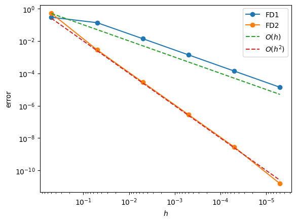

```python
plt.plot(h_, abs(errors), "o-", label=["FD1", "FD2"])
plt.gca().invert_xaxis()
# Add lines for perfect 1st and 2nd order.
loglog(h_, h_, "--", label="$O(h)$")
loglog(h_, h_**2, "--", label="$O(h^2)$")
xlabel("$h$")
ylabel("error")
legend();
```

## 5.5.2 Stability

The truncation error $\tau_f(h)$ of a finite-difference formula is dominated by a leading term  
$O(h^m)$ for an integer $m$. This error decreases as $h \to 0$.  
However, we have not yet accounted for the effects of roundoff error.  
To keep matters as simple as possible, let’s consider the forward difference

$$ \delta(h) = \frac{f(x + h) - f(x)}{h}. \quad \text{(5.5.4)} $$

As $h \to 0$, the numerator approaches zero even though the values $f(x + h)$ and $f(x)$  
are not necessarily near zero. This is the recipe for *subtractive cancellation error*!  
In fact, finite-difference formulas are inherently ill-conditioned as $h \to 0$.  
To be precise, recall that the condition number for the problem of computing  
$f(x + h) - f(x)$ is

$$ \kappa(h) = \frac{\max\{ |f(x + h)|, |f(x)| \}}{|f(x + h) - f(x)|}, \quad \text{(5.5.5)} $$

implying a relative error of size $\kappa(h)\varepsilon_{\text{mach}}$ in its computation.  
Hence, the numerical value we actually compute for $\delta$ is

$$ \begin{aligned} \tilde{\delta}(h) &= \frac{f(x + h) - f(x)}{h} (1 + \kappa(h)\varepsilon_{\text{mach}}) \\ &= \delta(h) + \frac{\max\{ |f(x + h)|, |f(x)| \}}{|f(x + h) - f(x)|} \cdot \frac{f(x + h) - f(x)}{h} \cdot \varepsilon_{\text{mach}}. \end{aligned} \quad \text{(5.5.6)} $$

Hence, as $h \to 0$,

$$ |\tilde{\delta}(h) - \delta(h)| = \frac{\max\{ |f(x + h)|, |f(x)| \}}{h}\,\varepsilon_{\text{mach}} \sim |f(x)|\,\varepsilon_{\text{mach}}\,h^{-1}. \quad \text{(5.5.7)} $$

Combining the truncation error and the roundoff error leads to

$$ |f'(x) - \tilde{\delta}(h)| \leq |\tau_f(h)| + |f(x)|\,\varepsilon_{\text{mach}}\,h^{-1}. \quad \text{(5.5.8)} $$

Equation (5.5.8) indicates that while the truncation error $\tau$ vanishes as $h$ decreases,  
the roundoff error actually *increases* thanks to the subtractive cancellation.  
At some value of $h$, the two error contributions will be of roughly equal size.  
This occurs when

$$ |f(x)|\,\varepsilon_{\text{mach}}\,h^{-1} \approx C h, \quad \text{or} \quad h \approx K\sqrt{\varepsilon_{\text{mach}}}, \quad \text{(5.5.9)} $$

for a constant $K$ that depends on $x$ and $f$, but not $h$.  
In summary, for a first-order finite-difference method,  
the optimum spacing between nodes is proportional to $\varepsilon_{\text{mach}}^{1/2}$.  
(This observation explains the choice of $\delta$ in *Function 4.6.1*.)

For a method of truncation order $m$, the details of the subtractive cancellation are a bit different, but the conclusion generalizes.

**Observation 5.5.1**

For computing with a finite-difference method of order $m$ in the presence of roundoff,  
the optimal spacing of nodes satisfies

$$ h_{\text{opt}} \approx \varepsilon_{\text{mach}}^{1/(m+1)}, \quad \text{(5.5.10)} $$

and the optimum total error is roughly $\varepsilon_{\text{mach}}^{m/(m+1)}$.

A different statement of the conclusion is that for a first-order formula, at most we can expect accuracy in only about half of the available machine digits. As $m$ increases, we get ever closer to using the full accuracy available. Higher-order finite-difference methods are both more efficient and less vulnerable to roundoff than low-order methods.

### Example 5.5.4 (Roundoff error in finite differences)

Let $f(x) = e^{-1.3x}$.  
We apply finite-difference formulas of first, second, and fourth order  
to estimate $f'(0) = -1.3$.

```python
f = lambda x: exp(-1.3 * x)
exact = -1.3

h_ = array([1 / 10**(n+1) for n in range(12)])
FD = np.zeros((len(h_), 3))
for (i, h) in enumerate(h_):
    nodes = h * linspace(-2, 2, 5)
    vals = f(nodes)
    FD[i, 0] = np.dot(array([0, 0, -1, 1, 0]) / h, vals)
    FD[i, 1] = np.dot(array([0, -1/2, 0, 1/2, 0]) / h, vals)
    FD[i, 2] = np.dot(array([1/12, -2/3, 0, 2/3, -1/12]) / h, vals)

results = PrettyTable()
results.add_column("h", h_)
results.add_column("FD1", FD[:, 0])
results.add_column("FD2", FD[:, 1])
results.add_column("FD4", FD[:, 2])
print(results)
```

```
+--------+---------------------+---------------------+---------------------+
|   h    |         FD1         |         FD2         |         FD4         |
+--------+---------------------+---------------------+---------------------+
|  0.1   | -1.2190456907943865 | -1.3036647620203023 | -1.2999875986418987 |
|  0.01  | -1.2915864979712381 | -1.3000366169760795 | -1.2999999987623418 |
| 0.001  | -1.2991553660477848 | -1.3000003661667279 | -1.2999999999999687 |
| 0.0001 | -1.2999155036613956 | -1.3000000036618076 | -1.3000000000006366 |
| 1e-05  | -1.2999915500404313 | -1.3000000000392902 | -1.3000000000174623 |
| 1e-06  |  -1.299999154987745 | -1.2999999999883585 |  -1.30000000007567  |
| 1e-07  | -1.2999999150633812 | -1.2999999998137355 |  -1.30000000144355  |
| 1e-08  | -1.2999999970197678 | -1.3000000044703484 |  -1.300000013783574 |
| 1e-09  | -1.2999999523162842 |  -1.300000011920929 |  -1.300000175833702 |
| 1e-10  | -1.2999992370605469 | -1.2999992370605469 | -1.2999999523162842 |
| 1e-11  | -1.3000030517578125 | -1.3000030517578125 | -1.3000011444091797 |
| 1e-12  |   -1.2999267578125  |  -1.29998779296875  | -1.3001251220703125 |
+--------+---------------------+---------------------+---------------------+
```

They all seem to be converging to -1.3. The convergence plot reveals some interesting structure to the errors, though.

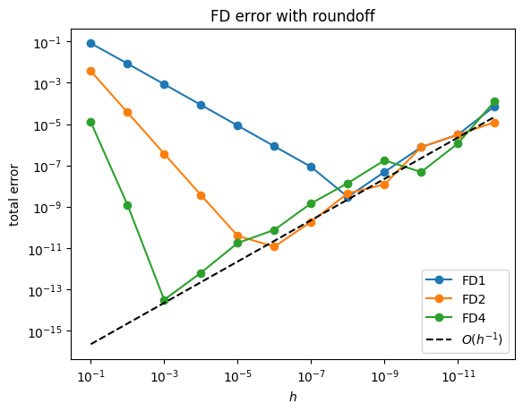

```python
loglog(h_, abs(FD[:, 0] + 1.3), "-o", label="FD1")
loglog(h_, abs(FD[:, 1] + 1.3), "-o", label="FD2")
loglog(h_, abs(FD[:, 2] + 1.3), "-o", label="FD4")
plt.gca().invert_xaxis()
plt.plot(h_, 0.1 * 2 ** (-52) / h_, "--", color="k", label="$O(h^{-1})$")
xlabel("$h$")
ylabel("total error")
plt.title("FD error with roundoff")
legend();
```

Again the graph is made so that $h$ decreases from left to right. The errors are dominated at first by truncation error, which decreases most rapidly for the fourth-order formula. However, increasing roundoff error eventually equals and then dominates the truncation error as $h$ continues to decrease. As the order of accuracy increases, the crossover point moves to the left (greater efficiency) and down (greater accuracy).